# Antibiotic Resistance

kammer

2024-11-29

# Introduction

Antibiotic resistance is increasing world wide in pathogenic microbial populations. Therapeutic and prophylactic use of antibiotics constitutes selective pressure that favors the evolution of antibiotic resistance strains. The durability of a resistance mutation in pathogens is partly determined by it overall fitness to the organism. Resistant mutations usually target key biochemical processes and can potentially impart a fitness cost to the microorganism.

# Methods

Evaluation of the relationship between resistance mutations and fitness was by analyzing data from the article *The fitness costs of antibiotic resistance mutations* authored by *Melnyk, Wong and Kassen*. The data focuses on fitness effects of single chromosomal mutations events that lead to the development of antibiotic resistance. A special emphasis is placed on gram positive organisms ,specifically Staph aureus.

## Evaluate the ranges of numeric variables in the data set

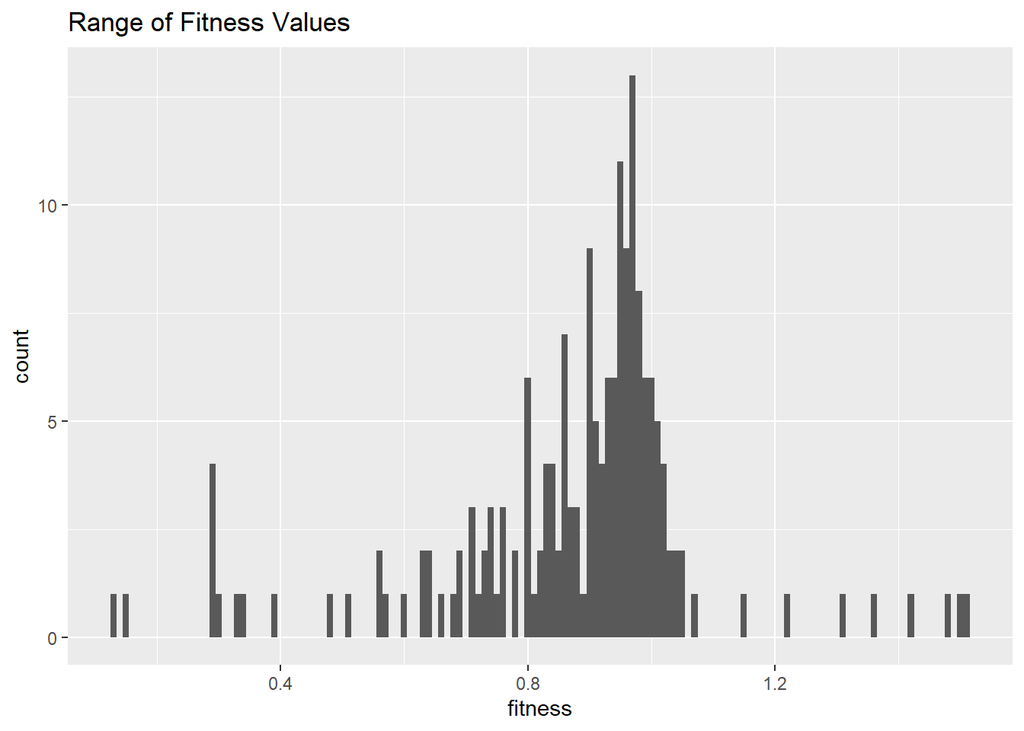

[output not shown]

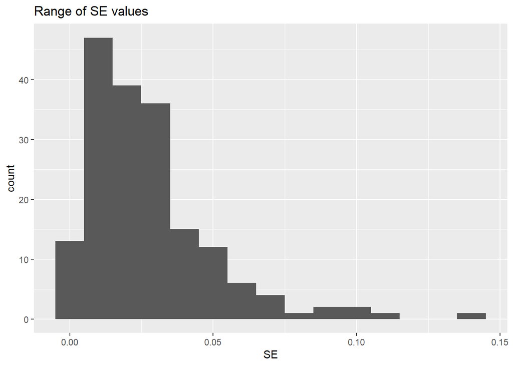

[output not shown]

[output cut: 256 more lines]

[output not shown]

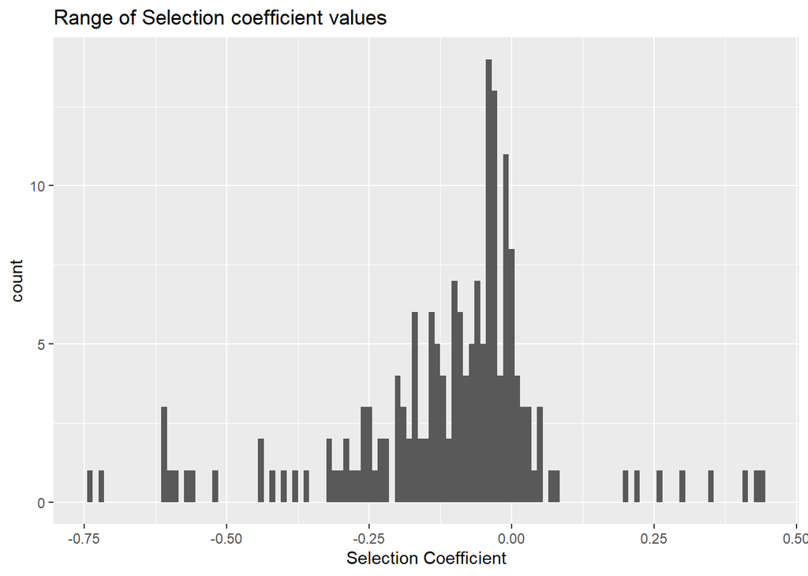

[output not shown]

[output cut: 250 more lines]

[output not shown]

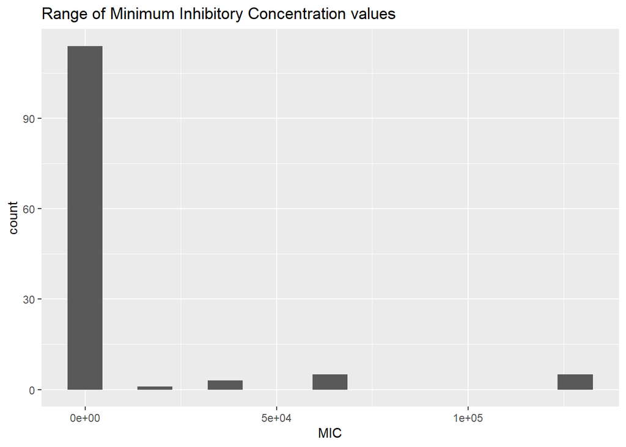

[output not shown]

# Relationship between Numeric Variables

The relationship between the numeric variables of 1)fitness, 2)SE and 3)Selection_coefficient are studied using 4 different approaches.

Scatterplot with color or size Encoding. The x and y axis encodes two ot the three variables. Color or size is used to represent the third variable.

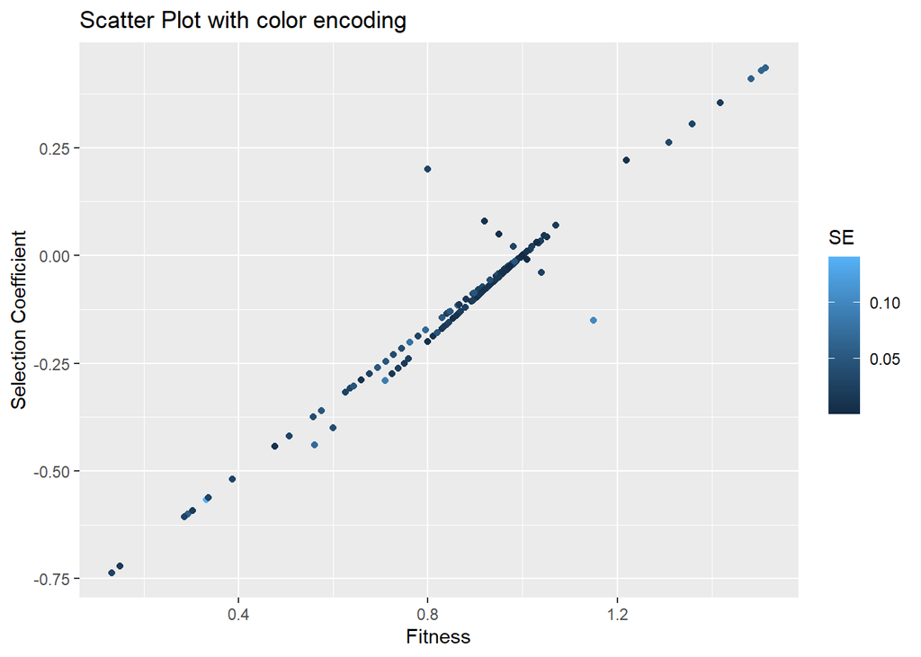

```r
ggplot(data = costR, mapping = aes(x = fitness, y = Selection_coefficient, color = SE))+
  geom_point()+labs(title = "Scatter Plot with color encoding",
                    x="Fitness",
                    y = "Selection Coefficient",
                    color = "SE")
```

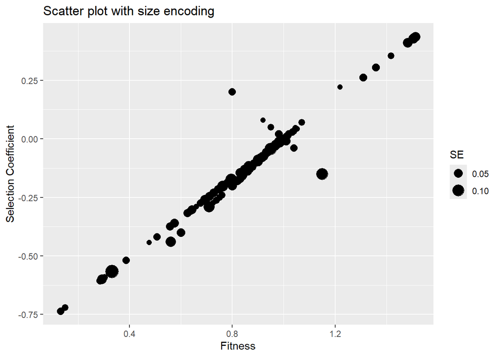

```r
ggplot(data = costR, mapping = aes(x = fitness, y = Selection_coefficient, size = SE))+
  geom_point()+
  labs(title = "Scatter plot with size encoding",
       x = "Fitness",
       y = "Selection Coefficient",
       size = "SE")
```

## Pair Plot (Scatterplot Matrix). The GGally package is used to create a scatterplot matrix to visualize pairwise relationships between multiple variables.

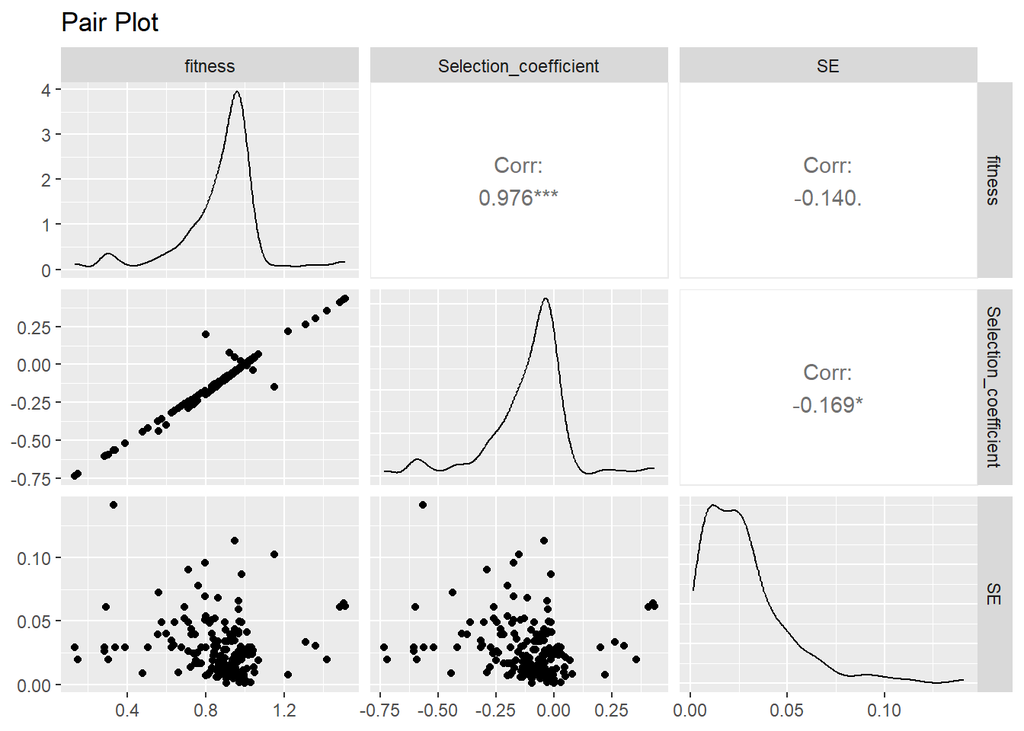

```r
numericonly <- costR %>%
  select(fitness, Selection_coefficient, SE)
#Use the data
ggpairs(numericonly, title = 'Pair Plot')
```

## Scatterplot Matrix using the Lattice package

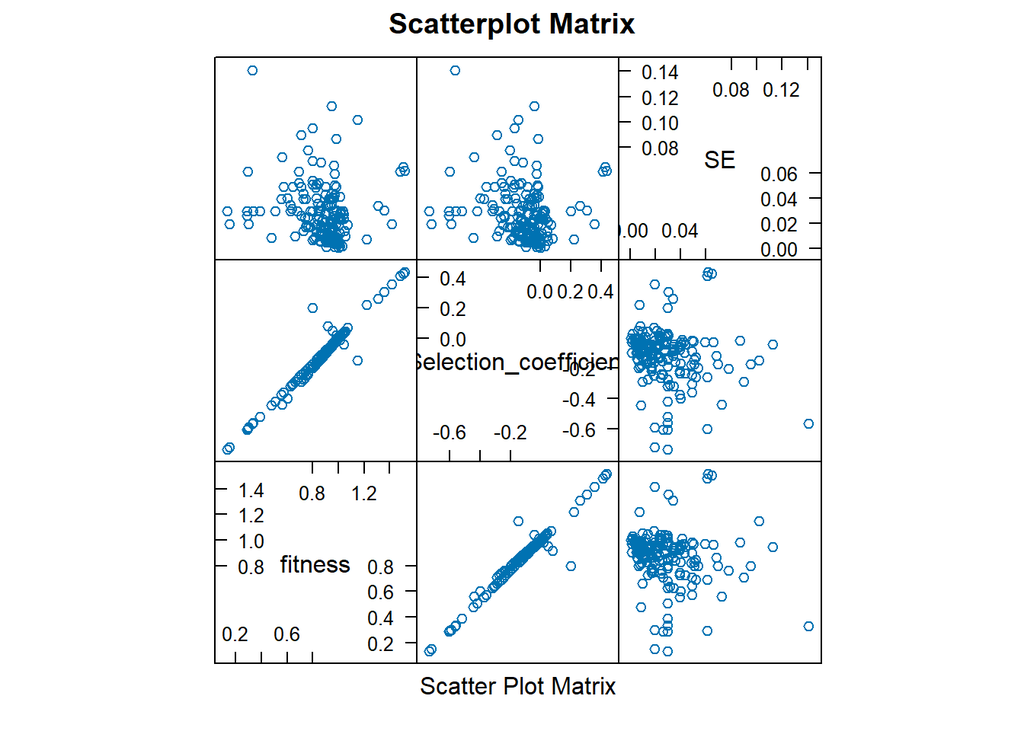

```r
splom(numericonly,
      main = "Scatterplot Matrix")
```

# Which mutations increae or decrease fitness

```r
  costR %>%
    select(gene_mutation, fitness) %>%
    na.omit() %>%
    filter(fitness <1.0) %>%
    distinct(gene_mutation)
```

```
##       gene_mutation
## 1       rpoB V1080I
## 2       rpoB V1080L
## 3       rpoB E1084K
## 4       rpoB D1101E
## 5       rpoB S1127L
## 6       rpoB S1127P
## 7        rpoC K334N
## 8        rpoC T925K
## 9        rpoC T925R
## 10      rpoC G1172C
## 11      rpoC G1172D
## 12        rpsL K43R
## 13        rpsL K43T
## 14        rpsL K88E
```

[output cut: 95 more lines]

```r
costR %>%
    select(gene_mutation, fitness) %>%
    na.omit() %>%
    filter(fitness> 1.0) %>%
    distinct()
```

```
##      gene_mutation fitness
## 1        DHFR L41F  1.0340
## 2        DHFR F99S  1.0510
## 3        DHFR F99Y  1.0170
## 4        grlA E84K  1.0200
## 5       grlA A116E  1.0200
## 6        parC S79Y  1.0040
## 7        parC D83Y  1.0700
## 8        gyrA S81Y  1.0100
## 9        gyrA S83A  1.0017
## 10      gyrB S464F  1.0391
## 11   gyrB delta9nt  1.0153
## 12 marR delta13 nt  1.0051
## 13       gyrA S83L  1.0100
## 14       parC S79Y  1.1500
## 15      rpoB I572F  1.4182
## 16      rpoB I572L  1.3587
## 17      rpoB 1572N  1.3094
## 18      rpoB I572F  1.4828
## 19      rpoB I572L  1.5134
## 20      rpoB 1572N  1.5049
## 21      rpoB H489Y  1.2200
## 22      rpoB D516G  1.0300
## 23      rpoB H526Y  1.0100
## 24       gyrA D94G  1.0400
## 25       gyrA D94Y  1.0100
```

No apparent relationship between increase or decrease in fitness and bacterial type

[output not shown]

[output cut: 1245 more lines]

The cell wall is an important target of mutations that confer antibiotic resistance, and thus intuitively, it seems possible that there may be a difference in fitness costs associated with antibiotic resistance between Gram-positive, which has a much thicker layer of peptidoglycan in their cell wall, and Gram-negative bacteria, which has a much thinner cell wall.

```r
GramFIT <- costR %>%
  filter(gram_stain == "negative" | gram_stain == "positive") %>%
  group_by(gram_stain) %>%
  summarise(mean_fitness = mean(fitness),
            IQR = IQR(fitness),
            Minumum = min(fitness),
            Maximum = max(fitness),
            Standard_deviation = sd(fitness))

GramFIT %>%
  gt() %>%
  tab_header(title = "Differences in fitness based on gram stain") %>%
  cols_label(gram_stain = "Gram stain",
             mean_fitness = "Mean Fitness",
             IQR = "Interquantile Range",
             Minumum="Minimum",
             Maximum= "Maximum",
             Standard_deviation= "Standard Deviation")
```

Differences in fitness based on gram stain

| Gram stain | Mean Fitness | Interquantile Range | Minimum | Maximum | Standard Deviation |
| --- | --- | --- | --- | --- | --- |
| negative | 0.9733961 | 0.1294500 | 0.725 | 1.5134 | 0.1678243 |
| positive | 0.8224603 | 0.2226997 | 0.133 | 1.2200 | 0.2154585 |

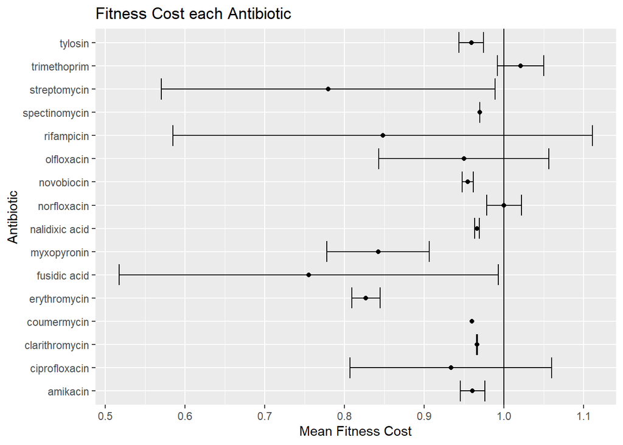

```r
costR %>%
  select(antibioticType, fitness) %>%
  group_by(antibioticType) %>%
  summarise(mean_cost = mean(fitness),
            stddev = sd(fitness, na.rm = TRUE),
            meansd_l = mean_cost - stddev,
            meansd_u = mean_cost + stddev) %>%
  ggplot(mapping = aes(x= mean_cost, y = antibioticType))+
  geom_point()+
  geom_vline(xintercept = 1)+
  geom_errorbar(mapping = aes(xmin = meansd_l, xmax = meansd_u))+
  labs(x = "Mean Fitness Cost", y = "Antibiotic")+
  ggtitle("Fitness Cost each Antibiotic")
```

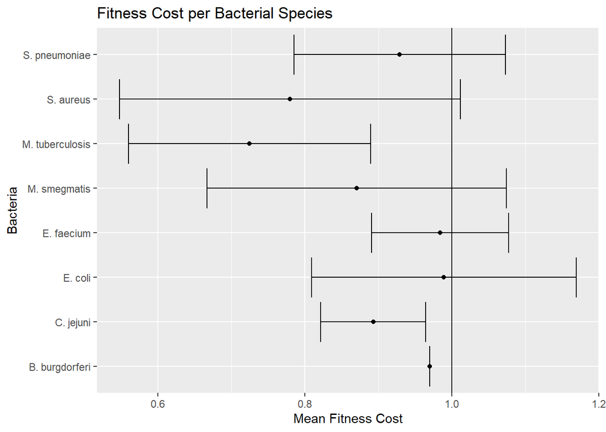

```r
costR %>%
  select(bacteria, fitness) %>%
  group_by(bacteria) %>%
  summarise(mean_cost = mean(fitness),
            stddev = sd(fitness, na.rm = TRUE),
            meansd_l = mean_cost - stddev,
            meansd_u = mean_cost + stddev) %>%
  ggplot(mapping = aes(x = mean_cost, y =bacteria))+
  geom_point()+
  geom_vline(xintercept = 1)+
  geom_errorbar(mapping = aes(xmin = meansd_l, xmax = meansd_u))+
  labs(x = "Mean Fitness Cost", y = "Bacteria")+
  ggtitle("Fitness Cost per Bacterial Species")
```

create a heat map with antibiotic and bacteria as the two categorical variables and fitness as a numeric variable.

```r
summary_data <- costR %>%
  drop_na() %>%
  group_by(bacteria, antibioticType, fitness) %>%
  summarize(MeanFITNESS = mean(fitness))
```

[figure not shown]

```r
ggplot(summary_data, aes(x = antibioticType, y = bacteria, fill = fitness)) +
  geom_tile() +
  scale_fill_gradient(low = "blue", high = "red") +
  theme_minimal() +
  labs(title = "Heat Map of Values by Antibiotic and Bacteria",
       x = "Antibiotic",
       y = "Bacteria",
       fill = "fitness")
```

## Analysis of Staph aureus gene mutations

What Staph aureus gene mutations associated with fitness is < 1, indicating less fit?

```r
BacteriaMoreFIT <- costR %>%
  select(bacteria, gene_mutation, gene_target, fitness) %>%
  filter(bacteria == "S. aureus" & fitness <1.0) %>%
  distinct(gene_mutation)
```

What Staph aureus gene mutations associated with fitness is > 1, indicating improved fitness?

```r
BacteriaLessFit <- costR %>%
  select(bacteria, gene_mutation, gene_target, fitness) %>%
  filter(bacteria == "S. aureus" & fitness > 1.0) %>%
  distinct(gene_mutation)
```